# A1_AhmedMoselhi

Ahmed Moselhi

2024-02-15

## 0.1 Introduction

### 0.1.1 About the paper

The following details early pre-processing steps of the GEO dataset associated with the publication: [Enhanced cortical neural stem cell identity through short SMAD/WNT inhibition in human cerebral organoids facilitates emergence of outer radial glial cells.](https://www-ncbi-nlm-nih-gov.myaccess.library.utoronto.ca/geo/query/acc.cgi?acc=GSE189981)

The authors of this paper investigate a novel culture protocol for 3D Brain Organoids which is thought to enhance the emergence of outer radial glia (oRGs). These cells are a vital component involved in cortical expansions.

Here is a schematic of the data:

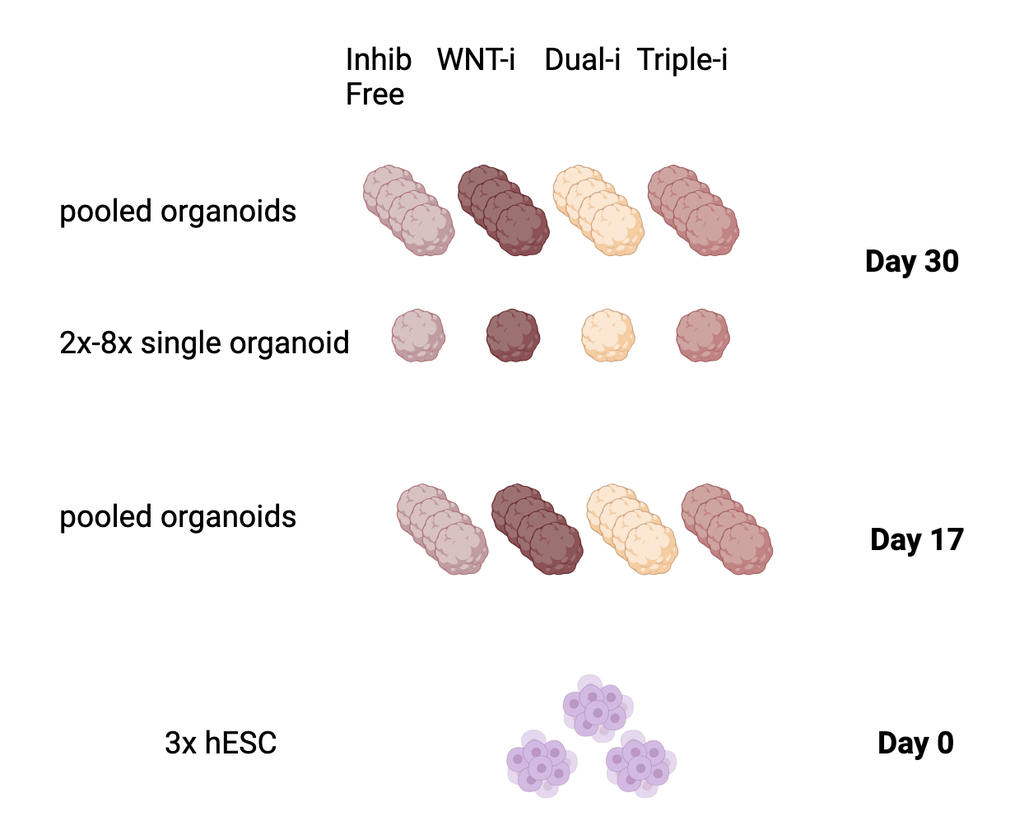

### 0.1.2 Packages

```r
# Install Bioconductor
if (!requireNamespace("BiocManager", quietly = TRUE))
    install.packages(BiocManager)

# Install openxlsx
if (!requireNamespace("openxlsx", quietly = TRUE))
     install.packages("openxlsx", dependencies = TRUE)

# Install GEOquery
if (!requireNamespace("GEOquery", quietly = TRUE))
    BiocManager::install(GEOquery)

# Install biomaRt
if (!requireNamespace("biomaRt", quietly = TRUE))
    BiocManager::install("biomaRt")

# Install data.table
if (!requireNamespace("data.table", quietly = TRUE))
    install.packages("data.table")

# Install edgeR
if (!requireNamespace("edgeR", quietly = TRUE))
    BiocManager::install("edgeR")
```

## 0.2 Accessing the Data

### 0.2.1 GEO dataset

```r
#Store GEO ID
geoid <-"GSE189981"
#Access GEO dataset
gse <- GEOquery::getGEO(geoid, GSEMatrix = FALSE)
```

### 0.2.2 Platform

```r
#Investigate dataset platform and output info
gpl <- names(GEOquery::GPLList(gse))[1]
gpl_info <- GEOquery::Meta(GEOquery::getGEO(gpl))
```

**Platform title:** Illumina HiSeq 2500 (Homo sapiens) An Illumina HiSeq 2500 was used to sequence the Bulkseq data.

**Submission date:** Mar 14 2013

**Last Update:** Mar 27 2019

**Organism:** Homo sapiens

**Number of GEO datasets using this platform:** 11584

### 0.2.3 Supplementary Files

```r
# Check Supplementary file
filenames <- GEOquery::getGEOSuppFiles(geoid, fetch_files = FALSE)
bulkseq_filename <- filenames$fname[3]

# Store path to Bulkseq file
file_location <- file.path(getwd(), geoid, bulkseq_filename)
```

Pre-processed Bulkseq data is stored in a Bulkseq excel file as RPKM.

### 0.2.4 Loading Data Files

```r
# Bulkseq file loading if not already downloaded then loaded
if (!file.exists(file_location)) {
  # Fetching file from GEO if it doesn't exist
  GEOquery::getGEOSuppFiles(geoid,
                  filter_regex = bulkseq_filename,
                  baseDir = getwd(),
                  fetch_files = TRUE)
} else if (!exists("bulkseq_data")) {
  # Loading file as object if not loaded
  raw_bulkseq_data <- as.data.frame(openxlsx::read.xlsx(file_location,
                             colNames = FALSE,
                             fillMergedCells = TRUE))

} else (print("File already loaded"))
```

## 0.3 Preprocessing

### 0.3.1 Sample Information

```r
# Storing list of samples
list_of_samples <- gse@gsms

# Converting the list of samples into a dataframe and cleaning
samples_info <- do.call(rbind, lapply(list_of_samples, function(x) {
  # For every element in the list pull sample info into data frame
  data.frame(
    SampleName = x@header$title,
    # Clean up information in every column to remove extra words
    CellLine = sub("cell line: ", "", x@header$characteristics_ch1[1]),
    Protocol = sub("protocol: ", "", x@header$characteristics_ch1[2]),
    Age = sub("age: ", "", x@header$characteristics_ch1[3]),
    CellType = sub("cell type: ", "", x@header$characteristics_ch1[4])
  )
  }
  ))

# Only select Bulkseq samples (H9 cell line) which are Wildtype
WT_bulk_sample_info <- samples_info[which
                                 (samples_info[,"CellLine"] == "H9"),]

kableExtra::kable_styling(knitr::kable(head(WT_bulk_sample_info)))
```

|  | SampleName | CellLine | Protocol | Age | CellType |
| --- | --- | --- | --- | --- | --- |
| GSM5911487 | D0_Embryonic stem cells WT 2 [H9_hESCs_Day 0] | H9 | hESCs | Day 0 | hESCs |
| GSM5911488 | D0_Embryonic stem cells WT 3 [H9_hESCs_Day 0] | H9 | hESCs | Day 0 | hESCs |
| GSM5911491 | D17_WT_pooled_NT [H9_Inhibitor-free_Day 17] | H9 | Inhibitor-free | Day 17 | Brain Organoid |
| GSM5911492 | D17_WT_pooled_XAV [H9_WNT-i_Day 17] | H9 | WNT-i | Day 17 | Brain Organoid |
| GSM5911493 | D17_WT_pooled_SBN [H9_Dual SMAD-i_Day 17] | H9 | Dual SMAD-i | Day 17 | Brain Organoid |
| GSM5911494 | D17_WT_pooled_SBNX [H9_Triple-i_Day 17] | H9 | Triple-i | Day 17 | Brain Organoid |

### 0.3.2 Cleaning Column Names

```r
# Merging column names
merged_colnames <- sapply(raw_bulkseq_data[1:3,], function(x) paste(x,collapse = " "))

#Clean list to use as reference when cleaning my column names
#This can also serve as a legend.
clean_labels <- list(
  "hgnc" = "HGNC",
  "hESCs" = "hESCs",
  "SINGLE" = "SI",
  "POOLED" = "PL",
  "Wildtype" = "WT",
  "Day 17" = "D17",
  "Day 30" = "D30",
  "WNT-i" = "WNT",
  "Triple-i" = "Triple",
  "Dual SMAD-i" = "Dual",
  "Inhibitor-free" = "IF",
  "Microcephaly" = "rmv")

#Cleaning column names by extracting necessary information
clean_colnames <- sapply(merged_colnames, function(x) {
  #Initialize my clean column names vector
  clean_colnames <- ""
  for (i in names(clean_labels)) {
    #For every entry in my "dirty" colnames list
    #I am checking it against sequences in the clean labels to grab experimental identifiers
    if ((grepl(i, x))==TRUE) {
      #Clean labels are appended to new colnames object
      clean_colnames <- paste(clean_colnames, sep = "_", clean_labels[[i]])
    }
  }
  #Removing any white space
  return(trimws(clean_colnames, whitespace = "_"))
  })

#Assigning colnames to my data and removing the old "column name" rows.
colnames(raw_bulkseq_data) <- c(clean_colnames)
bulkseq_data <- raw_bulkseq_data[-(1:3),]

#View legend
legend <- t(as.data.frame(clean_labels))
kableExtra::kable_styling(knitr::kable(legend,
             col.names = c("Old Identifier", "Column Label")))
```

| Old Identifier | Column Label |
| --- | --- |
| hgnc | HGNC |
| hESCs | hESCs |
| SINGLE | SI |
| POOLED | PL |
| Wildtype | WT |
| Day.17 | D17 |
| Day.30 | D30 |
| WNT.i | WNT |
| Triple.i | Triple |
| Dual.SMAD.i | Dual |
| Inhibitor.free | IF |
| Microcephaly | rmv |

```r
#View new column names
kableExtra::kable_styling(knitr::kable(head(bulkseq_data)))
```

|  | HGNC | hESCs | hESCs | hESCs | PL_WT_D17_IF | PL_WT_D17_WNT | PL_WT_D17_Dual | PL_WT_D17_Triple | PL_D17_IF_rmv | PL_D17_WNT_rmv | PL_D17_Dual_rmv | PL_D17_Triple_rmv | PL_D17_IF_rmv | PL_D17_WNT_rmv | PL_D17_Dual_rmv | PL_D17_Triple_rmv | PL_WT_D30_IF | PL_WT_D30_WNT | PL_WT_D30_Dual | PL_WT_D30_Triple | PL_D30_IF_rmv | PL_D30_Dual_rmv | PL_D30_Triple_rmv | PL_D30_IF_rmv | PL_D30_Dual_rmv | PL_D30_Triple_rmv | SI_D30_IF | SI_D30_IF | SI_D30_IF | … |
| --- | --- | --- | --- | --- | --- | --- | --- | --- | --- | --- | --- | --- | --- | --- | --- | --- | --- | --- | --- | --- | --- | --- | --- | --- | --- | --- | --- | --- | --- | --- |
| 4 | TSPAN6 | 31.472994386645599 | 33.391685986631003 | 31.377635985949301 | 29.3432715255374 | 29.141987442763 | 31.2053091700507 | 32.100628998810301 | 36.997014377295898 | 37.600782479283197 | 31.217968868409201 | 38.813816331501002 | 51.164694729475897 | 36.117590168963602 | 36.605733214469502 | 40.2469301835336 | 36.293114406250702 | 27.182114507087299 | 24.067895612252201 | 19.434941208409299 | 31.9410101880997 | 30.8854735422562 | 35.407806056863002 | 40.684642517166402 | 50.612989971139697 | 43.711662487962002 | 36.605630286888498 | 35.4952308157837 | 32.541883661268102 | … |
| 5 | TNMD | 0.95524531562624104 | 1.0189388792009 | 0.93592104523689701 | 0.381239740361073 | 0 | 0 | 0 | 0 | 0 | 0 | 0 | 6.6407652516650997E-2 | 0 | 4.94856074828154E-2 | 0 | 0.29816470661209699 | 0.73551970265450795 | 9.5690817425014493E-2 | 4.1903966805825303E-2 | 2.1280622752599401 | 0.29510436826335601 | 5.9602274048702801 | 1.1361178075173599 | 0.32659819231000398 | 1.12050635706776 | 2.8173602927760899 | 1.1678540189187001 | 0.69675093028216395 | … |
| 6 | DPM1 | 57.247448140699497 | 46.448342409232701 | 46.381207390923798 | 22.3188265564416 | 31.4121478297529 | 24.0407324569933 | 34.534106673533699 | 36.447584011698197 | 32.480127979535297 | 29.329739993001901 | 29.422605663366799 | 34.900605051708602 | 29.827052854016198 | 30.4297537115329 | 35.907539110226899 | 29.154431378922698 | 21.257149097706201 | 22.6349348083052 | 24.705634513969599 | 22.610000511958201 | 22.584836071141002 | 22.6221088810445 | 23.198061586290699 | 27.674899453637199 | 25.4593306145436 | 25.181094959356201 | 21.5764672814806 | 21.979980776212798 | … |
| 7 | SCYL3 | 2.90541358355796 | 2.9467231721600902 | 2.8036240468009601 | 2.7144983594387599 | 3.54448082224439 | 3.3373155462369799 | 3.16897676703136 | 4.60236745980127 | 3.8507586534051002 | 4.0720554136078198 | 4.67392911345953 | 3.3654721089408901 | 3.1677664744152199 | 2.36279614916646 | 1.81794123731132 | 5.2124527274539298 | 5.6240891268904898 | 4.1080585706459303 | 3.9664873470258901 | 5.2005767465639696 | 4.6504464068712599 | 5.4390152631442898 | 5.2196578675394196 | 5.24124006301974 | 5.6714530347483798 | 4.5575152442773099 | 3.7305868416939898 | 4.01986679085985 | … |
| 8 | C1orf112 | 3.9476156614446198 | 4.49975211683621 | 5.01617739936143 | 5.8174627047508096 | 3.9444826391568402 | 4.0539969358296197 | 5.6871765937268997 | 3.6826335292275298 | 5.8036689940076096 | 4.36681251637635 | 4.0583209474025601 | 5.1489446158094498 | 4.3645038519018096 | 4.6937080525209396 | 4.1879304978685399 | 1.49457757406284 | 1.4766135479915401 | 1.3052695358705799 | 2.1607186283327899 | 0.89556791376221201 | 1.3319231918637899 | 1.62921182522842 | 1.30207501757891 | 1.7030037277891299 | 2.12216705500254 | 1.1199686733226699 | 0.82149583645839197 | 0.82976302950033598 | … |
| 9 | FGR | 0 | 5.9113618921984599E-2 | 4.6477350430323E-2 | 0 | 0 | 0 | 0 | 0 | 7.3369961009418699E-2 | 0 | 0 | 0 | 0 | 1.50722338341531E-2 | 0 | 3.5536088756266099E-2 | 0 | 0 | 4.7861369578163497E-2 | 0 | 1.6852938170544601E-2 | 8.2516132853865196E-3 | 7.9854608840608902E-3 | 7.8532631820764399E-3 | 0 | 0 | 3.1853981575535498E-2 | 1.5916132204232599E-2 | … |

**Current Data Dimensions:** 18761, 52  
The data dimensions roughly align with the expected number of genes.

**Unique Identifier:** 1.8756^{4}

**Duplicated Identifier:** 2

### 0.3.3 Removing duplicates

```r
#Separate duplicated and unmapped genes from main dataframe
duplicated_unmapped <- bulkseq_data[-(grep("[A-Za-z]",bulkseq_data$HGNC)),]

# Removing 2 duplicated entries
duplicated_genes <- duplicated_unmapped$HGNC[duplicated(duplicated_unmapped$HGNC)]
unmapped <- duplicated_unmapped[-(grep(paste(duplicated_genes,collapse = "|"),
                                       duplicated_unmapped$HGNC)),]
```

### 0.3.4 Mapping identifier

```r
# Get ensembl mart object
ensembl<- biomaRt::useMart("ensembl", dataset = "hsapiens_gene_ensembl")

# Save ensembl attributes and filters
ensembl_attributes <- biomaRt::listAttributes(mart = ensembl, what = c("name","description"))
ensembl_filters <- biomaRt::listFilters(mart = ensembl, what = c("name","description"))

# Check for HGNC related ensembl attributes
hgnc_attributes <- ensembl_attributes[grepl("hgnc",ensembl_attributes$name),]
hgnc_filters <- ensembl_filters[grepl("hgnc",ensembl_filters$name),]

# Get my unmapped hgnc ids and add HGNC: for filtering
hgnc_ids <- unmapped$HGNC
hgnc_ids<- sapply(hgnc_ids, function(x) paste("HGNC:",x,sep = ""))

# Grab HGNC symbols based on HGNC ids
hgnc_symbols <- biomaRt::getBM(attributes = c('hgnc_id', 'hgnc_symbol'),
                 filters = 'hgnc_id',
                 values = hgnc_ids,
                 mart = ensembl)

kableExtra::kable_styling(knitr::kable(hgnc_symbols))
```

| hgnc_id | hgnc_symbol |
| --- | --- |
| HGNC:37135 | FAM41AY2 |
| HGNC:37226 | PHGR1 |
| HGNC:37500 | RNVU1-7 |
| HGNC:37865 | GLYATL1B |
| HGNC:38047 | UQCRHP4 |
| HGNC:38231 | MIR4253 |
| HGNC:38777 | USP9YP33 |
| HGNC:38961 | MIR3622B |
| HGNC:39326 | SNRPGP7 |
| HGNC:39508 | ATP5MC1P5 |
| HGNC:39873 | KRT8P39 |
| HGNC:40603 | UPK1A-AS1 |
| HGNC:41153 | XXYLT1-AS1 |
| HGNC:41883 | MIR4683 |

```r
# Strip HGNC ids to allow merging back
hgnc_symbols[1] <-sapply(hgnc_symbols[1], function(x) gsub("HGNC:","",x))

# Rename columns to match unmapped
hgnc_symbols <-as.matrix(hgnc_symbols)
colnames(hgnc_symbols) <- c("HGNC", "Symbol")
hgnc_symbols <-as.data.frame(hgnc_symbols)

# Subset out unmappable genes
mapped <- subset(unmapped, HGNC %in% hgnc_symbols$HGNC)
# Merge symbols back to unmapped genes to create mapped genes
mapped <- merge(mapped, hgnc_symbols, by = "HGNC", all = TRUE)
```

**How Many Identifiers did not map/were removed:** 9

### 0.3.5 Merging duplicated/unmapped subset

```r
# Order symbols at the beginning of dataframe and remove old HGNC Ids
mapped_ordered <- mapped[,c(53,2:52)]

# Rename Symbol to HGNC to prepare for rbind
colnames(mapped_ordered) <- colnames(bulkseq_data)

# Remove the old unmapped genes from the original dataset
bulkseq_data <- bulkseq_data[grep("[A-Za-z]",bulkseq_data$HGNC),]

# Combine mapped genes with original dataset
bulk_data <- rbind(bulkseq_data,mapped_ordered)

# Remove final duplicate gene with 0 expression
bulk_data <- bulk_data[(bulk_data$HGNC != "PHGR1"),]

# Make Gene Symbols rownames and remove redundant column
rownames(bulk_data) <- bulk_data$HGNC
bulk_data <- bulk_data[,-1]

kableExtra::kable_styling(knitr::kable(head(bulk_data)))
```

|  | hESCs | hESCs.1 | hESCs.2 | PL_WT_D17_IF | PL_WT_D17_WNT | PL_WT_D17_Dual | PL_WT_D17_Triple | PL_D17_IF_rmv | PL_D17_WNT_rmv | PL_D17_Dual_rmv | PL_D17_Triple_rmv | PL_D17_IF_rmv.1 | PL_D17_WNT_rmv.1 | PL_D17_Dual_rmv.1 | PL_D17_Triple_rmv.1 | PL_WT_D30_IF | PL_WT_D30_WNT | PL_WT_D30_Dual | PL_WT_D30_Triple | PL_D30_IF_rmv | PL_D30_Dual_rmv | PL_D30_Triple_rmv | PL_D30_IF_rmv.1 | PL_D30_Dual_rmv.1 | PL_D30_Triple_rmv.1 | SI_D30_IF | SI_D30_IF.1 | SI_D30_IF.2 | SI_D30_IF.3 | … |
| --- | --- | --- | --- | --- | --- | --- | --- | --- | --- | --- | --- | --- | --- | --- | --- | --- | --- | --- | --- | --- | --- | --- | --- | --- | --- | --- | --- | --- | --- | --- |
| TSPAN6 | 31.472994386645599 | 33.391685986631003 | 31.377635985949301 | 29.3432715255374 | 29.141987442763 | 31.2053091700507 | 32.100628998810301 | 36.997014377295898 | 37.600782479283197 | 31.217968868409201 | 38.813816331501002 | 51.164694729475897 | 36.117590168963602 | 36.605733214469502 | 40.2469301835336 | 36.293114406250702 | 27.182114507087299 | 24.067895612252201 | 19.434941208409299 | 31.9410101880997 | 30.8854735422562 | 35.407806056863002 | 40.684642517166402 | 50.612989971139697 | 43.711662487962002 | 36.605630286888498 | 35.4952308157837 | 32.541883661268102 | 36.435762772580503 | … |
| TNMD | 0.95524531562624104 | 1.0189388792009 | 0.93592104523689701 | 0.381239740361073 | 0 | 0 | 0 | 0 | 0 | 0 | 0 | 6.6407652516650997E-2 | 0 | 4.94856074828154E-2 | 0 | 0.29816470661209699 | 0.73551970265450795 | 9.5690817425014493E-2 | 4.1903966805825303E-2 | 2.1280622752599401 | 0.29510436826335601 | 5.9602274048702801 | 1.1361178075173599 | 0.32659819231000398 | 1.12050635706776 | 2.8173602927760899 | 1.1678540189187001 | 0.69675093028216395 | 0.78171122012746896 | … |
| DPM1 | 57.247448140699497 | 46.448342409232701 | 46.381207390923798 | 22.3188265564416 | 31.4121478297529 | 24.0407324569933 | 34.534106673533699 | 36.447584011698197 | 32.480127979535297 | 29.329739993001901 | 29.422605663366799 | 34.900605051708602 | 29.827052854016198 | 30.4297537115329 | 35.907539110226899 | 29.154431378922698 | 21.257149097706201 | 22.6349348083052 | 24.705634513969599 | 22.610000511958201 | 22.584836071141002 | 22.6221088810445 | 23.198061586290699 | 27.674899453637199 | 25.4593306145436 | 25.181094959356201 | 21.5764672814806 | 21.979980776212798 | 25.807156457356498 | … |
| SCYL3 | 2.90541358355796 | 2.9467231721600902 | 2.8036240468009601 | 2.7144983594387599 | 3.54448082224439 | 3.3373155462369799 | 3.16897676703136 | 4.60236745980127 | 3.8507586534051002 | 4.0720554136078198 | 4.67392911345953 | 3.3654721089408901 | 3.1677664744152199 | 2.36279614916646 | 1.81794123731132 | 5.2124527274539298 | 5.6240891268904898 | 4.1080585706459303 | 3.9664873470258901 | 5.2005767465639696 | 4.6504464068712599 | 5.4390152631442898 | 5.2196578675394196 | 5.24124006301974 | 5.6714530347483798 | 4.5575152442773099 | 3.7305868416939898 | 4.01986679085985 | 4.4281886696359702 | … |
| C1orf112 | 3.9476156614446198 | 4.49975211683621 | 5.01617739936143 | 5.8174627047508096 | 3.9444826391568402 | 4.0539969358296197 | 5.6871765937268997 | 3.6826335292275298 | 5.8036689940076096 | 4.36681251637635 | 4.0583209474025601 | 5.1489446158094498 | 4.3645038519018096 | 4.6937080525209396 | 4.1879304978685399 | 1.49457757406284 | 1.4766135479915401 | 1.3052695358705799 | 2.1607186283327899 | 0.89556791376221201 | 1.3319231918637899 | 1.62921182522842 | 1.30207501757891 | 1.7030037277891299 | 2.12216705500254 | 1.1199686733226699 | 0.82149583645839197 | 0.82976302950033598 | 0.77743604466328398 | … |
| FGR | 0 | 5.9113618921984599E-2 | 4.6477350430323E-2 | 0 | 0 | 0 | 0 | 0 | 7.3369961009418699E-2 | 0 | 0 | 0 | 0 | 1.50722338341531E-2 | 0 | 3.5536088756266099E-2 | 0 | 0 | 4.7861369578163497E-2 | 0 | 1.6852938170544601E-2 | 8.2516132853865196E-3 | 7.9854608840608902E-3 | 7.8532631820764399E-3 | 0 | 0 | 3.1853981575535498E-2 | 1.5916132204232599E-2 | 1.7856910675443399E-2 | … |

**Current data dimension:** 18746, 51

### 0.3.6 Extracting relevant experiments

```r
#Removing Microcephaly table which was tagged with rmv
bulk_data <- bulk_data[,-c((grep("rmv",(colnames(bulkseq_data)))))]
```

**Current data dimension:** 18746, 37